# Level Set

The `LevelSet` module implements a fire spread simulator using the **level set method**. A signed distance function `φ(x, y, t)` implicitly tracks the fire front:

| Region | Condition | Meaning |
| --- | --- | --- |
| Burned | `φ < 0` | Fire has passed |
| Front | `φ = 0` | Active fire perimeter |
| Unburned | `φ > 0` | Fuel ahead of fire |

The front evolves according to the Hamilton-Jacobi equation:

$$\frac{\partial \phi}{\partial t} + F |\nabla \phi| = 0$$

where $F(x, y, t) \geq 0$ is the local spread rate (e.g. from the Rothermel model).

## `LevelSetGrid`

```julia
grid = LevelSetGrid(100, 100, dx=30.0)
```

```
LevelSetGrid{Float64} 100×100 (t=0.0, burned=0/10000)
```

### Coordinates

```julia
xs = xcoords(grid)
println("x: $(first(xs)) to $(last(xs)) m  ($(length(xs)) cells)")

ys = ycoords(grid)
println("y: $(first(ys)) to $(last(ys)) m  ($(length(ys)) cells)")
```

```
x: 15.0 to 2985.0 m  (100 cells)
y: 15.0 to 2985.0 m  (100 cells)
```

## Ignition

```julia
ignite!(grid, 1500.0, 1500.0, 100.0)
grid
```

```
LevelSetGrid{Float64} 100×100 (t=0.0, burned=32/10000)
```

## Queries

```julia
burn_area(grid)  # m²
```

```
28800.0
```

```julia
sum(burned(grid))  # number of burned cells
```

```
32
```

## Advancing the Front

The spread rate field `F` has the same dimensions as the grid. Each cell specifies the local spread rate in m/min.

```julia
F = fill(10.0, size(grid))  # uniform 10 m/min everywhere

for _ in 1:20
    advance!(grid, F, 0.5)
end

grid
```

```
LevelSetGrid{Float64} 100×100 (t=10.0, burned=264/10000)
```

### CFL Condition

The time step `dt` must satisfy the **Courant–Friedrichs–Lewy (CFL) condition** for numerical stability:

$$\text{dt} < \frac{\text{dx}}{\max(F)}$$

If `dt` is too large relative to `dx` and the maximum spread rate, the upwind scheme becomes unstable and `φ` values will diverge. For example, with `dx = 30 m` and `max(F) = 31 m/min`, you need `dt < 0.97 min`.

The `simulate!` function in the `SpreadModel` module does **not** automatically enforce the CFL condition — you are responsible for choosing a safe `dt`.

## Reinitialization

Over many time steps, `φ` can drift away from a true signed distance function (gradients become too flat or too steep). Periodic reinitialization restores `|∇φ| ≈ 1`, which keeps the upwind scheme accurate.

```julia
reinitialize!(grid)
grid
```

```
LevelSetGrid{Float64} 100×100 (t=10.0, burned=264/10000)
```

## Plotting

### Standard Makie Plots

The `LevelSetGrid` integrates with Makie’s `heatmap`, `contour`, `contourf`, and `surface` via `convert_arguments`:

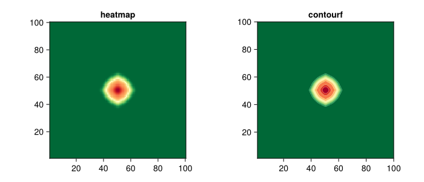

```julia
fig = Figure(size=(700, 300))
ax1 = Axis(fig[1, 1], title="heatmap", aspect=DataAspect())
heatmap!(ax1, grid, colormap=:RdYlGn)

ax2 = Axis(fig[1, 2], title="contourf", aspect=DataAspect())
contourf!(ax2, grid, colormap=:RdYlGn)
fig
```

### `fireplot`

The `fireplot` recipe combines a heatmap of `φ` with a contour line at the fire front:

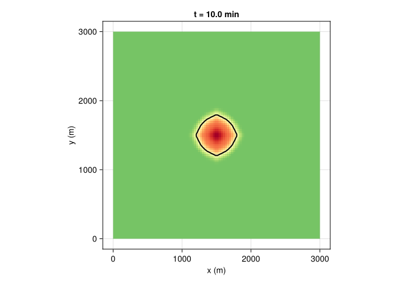

```julia
fig = Figure()
ax = Axis(fig[1, 1], title="t = $(grid.t) min", aspect=DataAspect(),
    xlabel="x (m)", ylabel="y (m)")
fireplot!(ax, grid)
fig
```

## Full Example

Simulate fire spread with a spatially varying spread rate and visualize snapshots:

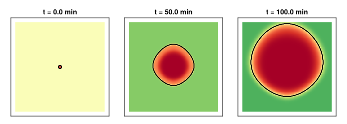

```julia
# Fresh grid with ignition
g = LevelSetGrid(200, 200, dx=15.0)
ignite!(g, 1500.0, 1500.0, 50.0)

# Spread rate: faster on the right side
F = [5.0 + 10.0 * (j / 200)
    for i in 1:200, j in 1:200]

fig = Figure(size=(700, 250))
times = [0, 50, 100]
for (col, target_t) in enumerate(times)
    while g.t < target_t
        advance!(g, F, 0.25)
    end
    col > 1 && reinitialize!(g)
    t = round(g.t, digits=1)
    ax = Axis(fig[1, col],
        title="t = $t min",
        aspect=DataAspect())
    fireplot!(ax, g)
    hidedecorations!(ax)
end
fig
```

## References

- Osher, S. & Sethian, J.A. (1988). *Fronts propagating with curvature-dependent speed.* J. Computational Physics, 79(1), 12–49.
- Mallet, V., Keyes, D.E., & Fendell, F.E. (2009). *Modeling wildland fire propagation with level set methods.* Computers & Mathematics with Applications.